# Liotta_Dario_Rlab06

2024-06-07

```r
library(rstan)
```

```r
library(ggplot2)
library(bayesplot)
```

# Exercise 1

```r
X1 <- c(109, 65, 22, 3, 1, 0)
X2 <- c(144, 91, 32, 11, 2, 0)
```

A uniform prior and a Poisson likelihood gives a Gamma posterior $\sim t^{k-1}e^{-\mu t}$ where

$$\begin{cases}k=\sum\limits_{i=1}^nx_i+1\\
\mu=n\end{cases}$$

with mean and variance given by

$$E(\lambda)=\frac{k}{\mu} \hspace{1cm}
var(\lambda)=\frac{k}{\mu^2}$$

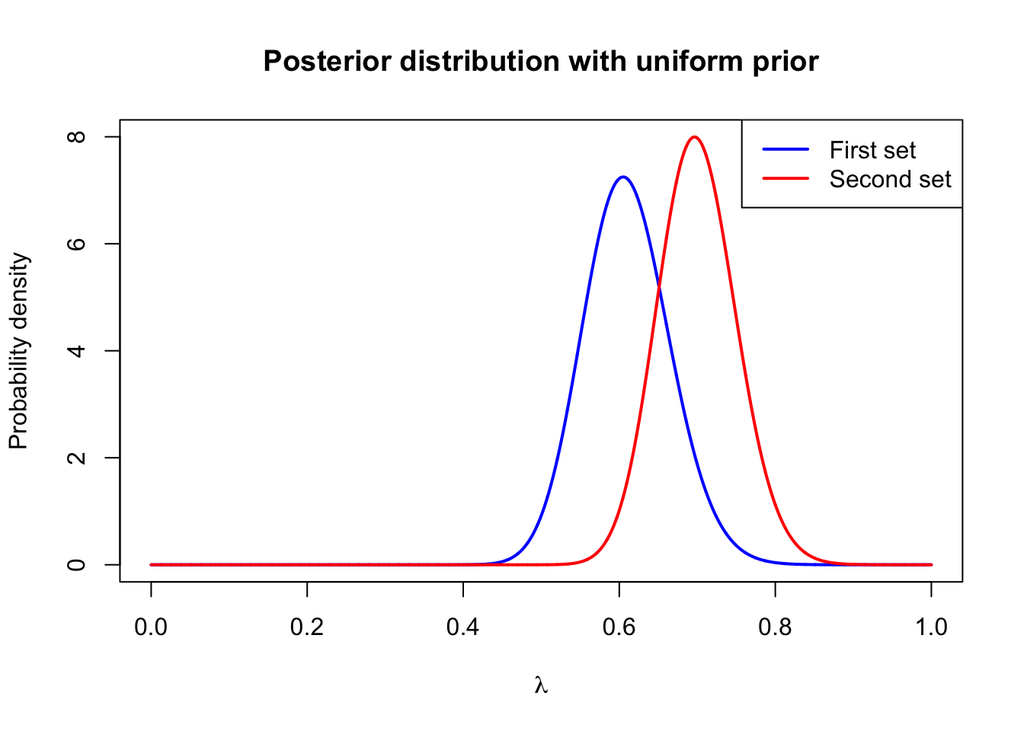

```r
lambdas <- seq(0, 1, by = 10^(-4))

k1 <- 0
for(i in 1:length(X1)) {
  k1 <- k1 + (i-1) * X1[i]
}
mu1 <- sum(X1)
values1  <- dgamma(lambdas, shape = k1, rate = mu1)

k2 <- 0
for(i in 1:length(X2)) {
  k2 <- k2 + (i-1) * X2[i]
}
mu2 <- sum(X2)
values2  <- dgamma(lambdas, shape = k2, rate = mu2)

plot(lambdas, values1,
     xlab = expression(lambda),
     ylab = "Probability density",
     main = "Posterior distribution with uniform prior",
     type = "l", lwd = 2, col = "blue",
     ylim = c(0, max(values2))
     )
lines(lambdas, values2, type = "l", lwd = 2, col = "red")
legend("topright", legend = c("First set", "Second set"), col = c("blue", "red"), lwd = 2)
```

```r
cat(sprintf("About the first set of observations:\n"))
```

```
## About the first set of observations:
```

```r
cat(sprintf("Mean: %.4f\n", k1/mu1))
```

```
## Mean: 0.6100
```

```r
cat(sprintf("Variance: %.4f\n", k1/(mu1^2)))
```

```
## Variance: 0.0031
```

```r
cat(sprintf("Median: %.4f\n", qgamma(0.5, shape = k1, rate = mu1)))
```

```
## Median: 0.6083
```

```r
cat(sprintf("95%% credibility interval: [%.4f, %.4f]\n", qgamma(0.025, shape = k1, rate = mu1), qgamma(0.975, shape = k1, rate = mu1)))
```

```
## 95% credibility interval: [0.5066, 0.7229]
```

```r
cat(sprintf("\n\nAbout the second set of observations:\n"))
```

```
##
##
## About the second set of observations:
```

```r
cat(sprintf("Mean: %.4f\n", k2/mu2))
```

```
## Mean: 0.7000
```

```r
cat(sprintf("Variance: %.4f\n", k2/(mu2^2)))
```

```
## Variance: 0.0025
```

```r
cat(sprintf("Median: %.4f\n", qgamma(0.5, shape = k2, rate = mu2)))
```

```
## Median: 0.6988
```

```r
cat(sprintf("95%% credibility interval: [%.4f, %.4f]\n", qgamma(0.025, shape = k2, rate = mu2), qgamma(0.975, shape = k2, rate = mu2)))
```

```
## 95% credibility interval: [0.6054, 0.8013]
```

Using a Jeffrey prior changes only the shape parameter, which becomes $k=\sum\limits_{i=1}^nx_i+\frac{1}{2}$, so we can just pass from $k$ to $k-\frac{1}{2}$ and do the same calculations.

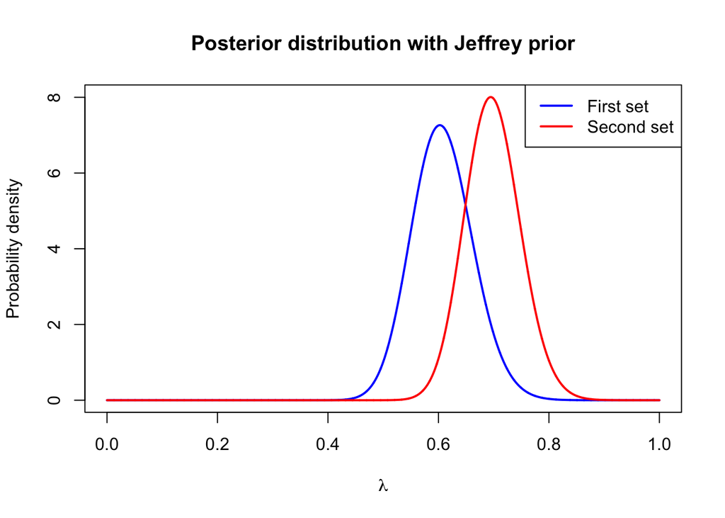

```r
k1 <- k1 - 0.5
k2 <- k2 - 0.5

values1  <- dgamma(lambdas, shape = k1, rate = mu1)
values2  <- dgamma(lambdas, shape = k2, rate = mu2)

plot(lambdas, values1,
     xlab = expression(lambda),
     ylab = "Probability density",
     main = "Posterior distribution with Jeffrey prior",
     type = "l", lwd = 2, col = "blue",
     ylim = c(0, max(values2))
    )
lines(lambdas, values2, type = "l", lwd = 2, col = "red")
legend("topright", legend = c("First set", "Second set"), col = c("blue", "red"), lwd = 2)
```

```r
cat(sprintf("About the first set of observations:\n"))
```

```
## About the first set of observations:
```

```r
cat(sprintf("Mean: %.4f\n", k1/mu1))
```

```
## Mean: 0.6075
```

```r
cat(sprintf("Variance: %.4f\n", k1/(mu1^2)))
```

```
## Variance: 0.0030
```

```r
cat(sprintf("Median: %.4f\n", qgamma(0.5, shape = k1, rate = mu1)))
```

```
## Median: 0.6058
```

```r
cat(sprintf("95%% credibility interval: [%.4f, %.4f]\n", qgamma(0.025, shape = k1, rate = mu1), qgamma(0.975, shape = k1, rate = mu1)))
```

```
## 95% credibility interval: [0.5043, 0.7202]
```

```r
cat(sprintf("\n\nAbout the second set of observations:\n"))
```

```
##
##
## About the second set of observations:
```

```r
cat(sprintf("Mean: %.4f\n", k2/mu2))
```

```
## Mean: 0.6982
```

```r
cat(sprintf("Variance: %.4f\n", k2/(mu2^2)))
```

```
## Variance: 0.0025
```

```r
cat(sprintf("Median: %.4f\n", qgamma(0.5, shape = k2, rate = mu2)))
```

```
## Median: 0.6970
```

```r
cat(sprintf("95%% credibility interval: [%.4f, %.4f]\n", qgamma(0.025, shape = k2, rate = mu2), qgamma(0.975, shape = k2, rate = mu2)))
```

```
## 95% credibility interval: [0.6038, 0.7994]
```

# Exercise 2

```r
y1    <- c(rep(0, 109), rep(1, 65), rep(2, 22), rep(3, 3), rep(4, 1))
y2    <- c(rep(0, 144), rep(1, 91), rep(2, 32), rep(3, 11), rep(4, 2))
data1 <- list(N = length(y1), y = y1)
data2 <- list(N = length(y2), y = y2)

model_string_uniform =
  "
    data {
      int <lower=0> N;
      int y[N];
    }

    parameters {
      real <lower=0> Lambda;
    }

    model {
      y ~ poisson (Lambda);
    }
  "

model_string_jeffrey =
  "
    data {
      int <lower=0> N;
      int y[N];
    }

    parameters {
      real <lower=0> Lambda;
    }

    model {
      target += -0.5*log(Lambda);
      y ~ poisson (Lambda);
    }
  "
```

```r
posterior_analysis <- function(model_string, data_list, bin_width = 0.01) {
  stan_m  <- stan_model(model_code = model_string)
  stanFit <- sampling(object = stan_m,
                      data = data_list,
                      chains = 2,
                      iter = 10000,
                      warmup = 1000,
                      thin = 1)

  hist_plot <- mcmc_hist(stanFit, pars = c("Lambda"), binwidth = bin_width) +
               labs(title = "Posterior histogram of λ",
                    x = expression(lambda),
                    y = "Frequency") +
               theme_minimal() +
               theme(plot.title = element_text(hjust = 0.5))

  summary_df <- as.data.frame(summary(stanFit)$summary)
  par_values <- summary_df["Lambda", ]

  cat(sprintf("\n\n\n"))
  cat(sprintf("Mean: %.4f\n", par_values["mean"]))
  cat(sprintf("Variance: %.4f\n", par_values["sd"]^2))
  cat(sprintf("Median: %.4f\n", par_values["50%"]))
  cat(sprintf("95%% credibility interval: [%.4f, %.4f]\n", par_values["2.5%"], par_values["97.5%"]))

  print(hist_plot)
}
```

```r
posterior_analysis(model_string_uniform, data1)
```

```
## Trying to compile a simple C file
```

[output not shown]

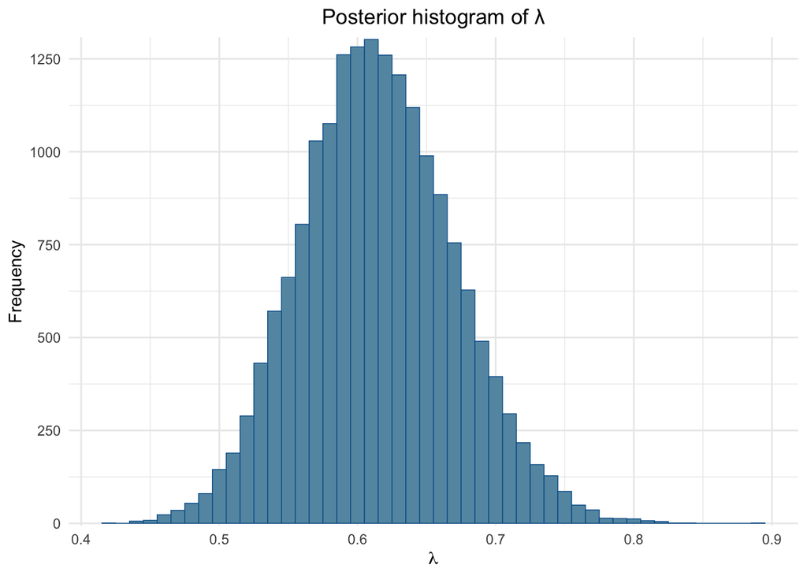

```r
posterior_analysis(model_string_uniform, data2)
```

```
## Trying to compile a simple C file
```

[output not shown]

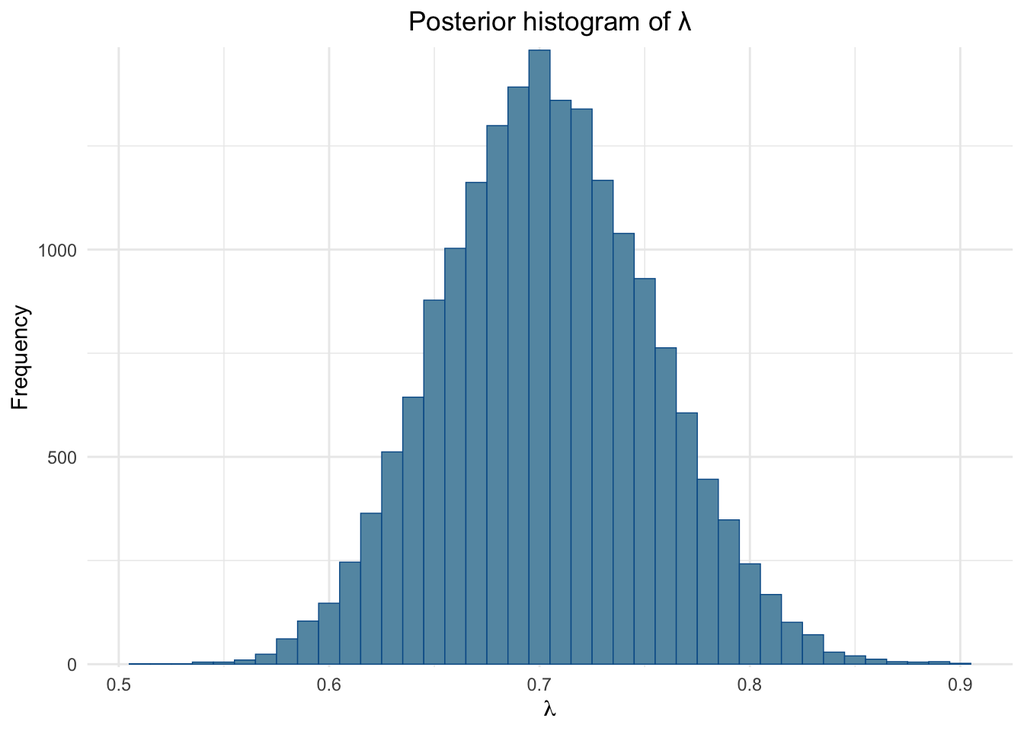

```r
posterior_analysis(model_string_jeffrey, data1)
```

```
## Trying to compile a simple C file
```

[output not shown]

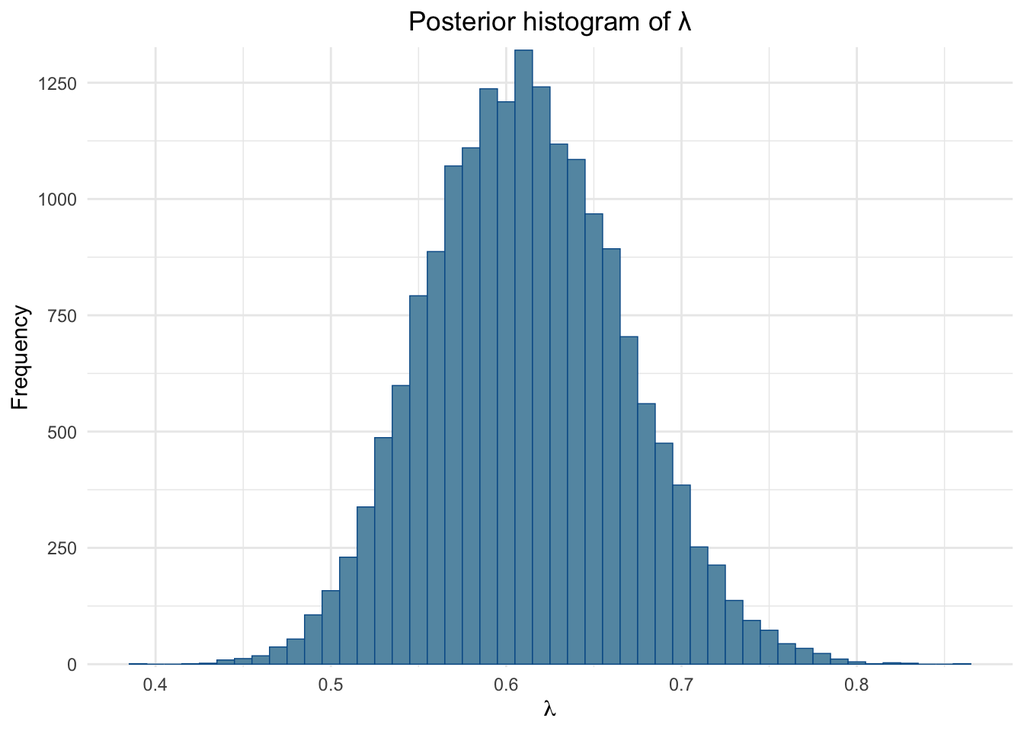

```r
posterior_analysis(model_string_jeffrey, data2)
```

```
## Trying to compile a simple C file
```

[output not shown]

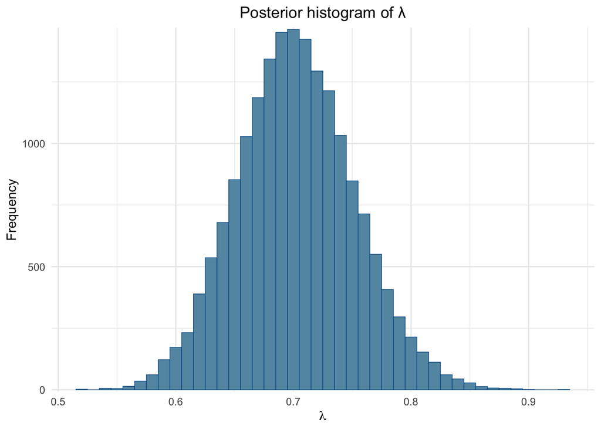

# Exercise 3

*(a) find the frequentist estimator for p*

Given $y$ samples with high bacter level on a total of $n$, the frequentist estimator will be given by $\frac{y}{n}$.

```r
y <- 11
n <- 116

cat(sprintf("Frequentist estimator for p: %.3f", y/n))
```

```
## Frequentist estimator for p: 0.095
```

*(b) using a Beta(1, 10) prior for p, calculate and posterior distribution P (p y)*

Given a beta prior $P(p|\alpha,\beta)$ and a binomial likelihood $P(y|n,p)$, the posterior will be a beta of the form $P(p|\alpha+y,\beta+n-y)$, so we find a posterior:

$$Beta(p|1+11,10+116-11)=Beta(p|12,115)$$

*(c) find the bayesian estimator for p, the posterior mean and variance, and a 95% credible interval*

The bayesian estimator will be given by the mean of the posterior distribution, which, for a beta distribution, is

$$E(p)=\frac{\alpha}{\alpha+\beta}$$

```r
alpha <- 12
beta  <- 115

cat(sprintf("Bayesian estimator for p: %.3f", alpha/(alpha+beta)))
```

```
## Bayesian estimator for p: 0.094
```

The variance is

$$\sigma(p)=\frac{\alpha\beta}{(\alpha+\beta)^2(\alpha+\beta+1)}$$

```r
sigma_p <- (alpha*beta) / ((alpha+beta)*(alpha+beta)*(alpha+beta+1))

cat(sprintf("Variance: %.5f", sigma_p))
```

```
## Variance: 0.00067
```

Lastly, let’s find the $95%$ credibility interval.

```r
cat(sprintf("95%% credibility interval: [%.3f, %.3f]", qbeta(0.025, alpha, beta), qbeta(0.975, alpha, beta)))
```

```
## 95% credibility interval: [0.050, 0.151]
```

*(d) test the hypothesis*

$$H_0:p=0.1 \ \ \text{versus} \ \
H_1:p\neq0.1$$

*at 5% level of significance with both the frequentist and bayesian approach*

```r
binom.test(x = y, n = n, p = 0.1)
```

```
##
##  Exact binomial test
##
## data:  y and n
## number of successes = 11, number of trials = 116, p-value = 1
## alternative hypothesis: true probability of success is not equal to 0.1
## 95 percent confidence interval:
##  0.04829409 0.16333954
## sample estimates:
## probability of success
##             0.09482759
```

Since $0.1$ also falls into the $95%$ credibility interval for the posterior distribution, we accept the hypothesis with both the frequentist and the bayesian approach.

*(e) find the frequentist estimator for p*

```r
y <- 9
n <- 165

cat(sprintf("Frequentist estimator for p: %.3f", y/n))
```

```
## Frequentist estimator for p: 0.055
```

*(f) find a bayesian estimator for p, assuming both a Beta(1,10) prior for p, and assuming the posterior probability of the older measurement as the prior for the new one.*

Assuming a $Beta(1,10)$ prior:

$$\begin{cases}\alpha=1+9=10\\
\beta=10+165-9=166\end{cases}$$

```r
alpha <- 10
beta  <- 166

cat(sprintf("Bayesian estimator for p: %.3f", alpha/(alpha+beta)))
```

```
## Bayesian estimator for p: 0.057
```

Instead, assuming the previous posterior as a prior:

$$\begin{cases}\alpha=12+9=21\\
\beta=115+165-9=271\end{cases}$$

```r
alpha <- 21
beta  <- 271

cat(sprintf("Bayesian estimator for p: %.3f", alpha/(alpha+beta)))
```

```
## Bayesian estimator for p: 0.072
```

*(g) find the bayesian estimator for p, the posterior mean and variance, and a 95% credible interval*

```r
alpha <- 10
beta  <- 166
sigma_p <- (alpha*beta) / ((alpha+beta)*(alpha+beta)*(alpha+beta+1))

cat(sprintf("Considering a Beta(1, 10) prior:\n"))
```

```
## Considering a Beta(1, 10) prior:
```

```r
cat(sprintf("Variance: %.5f\n", sigma_p))
```

```
## Variance: 0.00030
```

```r
cat(sprintf("95%% credibility interval: [%.3f, %.3f]", qbeta(0.025, alpha, beta), qbeta(0.975, alpha, beta)))
```

```
## 95% credibility interval: [0.028, 0.095]
```

```r
alpha <- 21
beta  <- 271
sigma_p <- (alpha*beta) / ((alpha+beta)*(alpha+beta)*(alpha+beta+1))

cat(sprintf("\n\nConsidering the previous posterior as prior:\n"))
```

```
##
##
## Considering the previous posterior as prior:
```

```r
cat(sprintf("Variance: %.5f\n", sigma_p))
```

```
## Variance: 0.00023
```

```r
cat(sprintf("95%% credibility interval: [%.3f, %.3f]", qbeta(0.025, alpha, beta), qbeta(0.975, alpha, beta)))
```

```
## 95% credibility interval: [0.045, 0.104]
```

*(h) test the hypothesis*

$$H_0:p=0.1 \ \ \text{versus} \ \
H_1:p\neq0.1$$

*at 5% level of significance with both the frequentist and bayesian approach*

```r
binom.test(x = y, n = n, p = 0.1)
```

```
##
##  Exact binomial test
##
## data:  y and n
## number of successes = 9, number of trials = 165, p-value = 0.05112
## alternative hypothesis: true probability of success is not equal to 0.1
## 95 percent confidence interval:
##  0.02524192 0.10101679
## sample estimates:
## probability of success
##             0.05454545
```

While $H_0$ is accepted considering the frequentist approach, the bayesian approach depends on the prior chosen: with the previous posterior $0.1$ is inside the $95%$ confidence interval, but with the $Beta(1,10)$ prior that is not the case, so the hypothesis $H_0$ is not accepted.